# Lab 4: Video Games

## Setup

Today, we will be looking at the dataset provided at this website: https://www.kaggle.com/gregorut/videogamesales

Familiarize yourself with the data. Then download the dataset and save it somewhere on your computer.

Set up your R Markdown document, and read in this dataset.

## Replicate a plot

Use your R skills to re-create this plot:

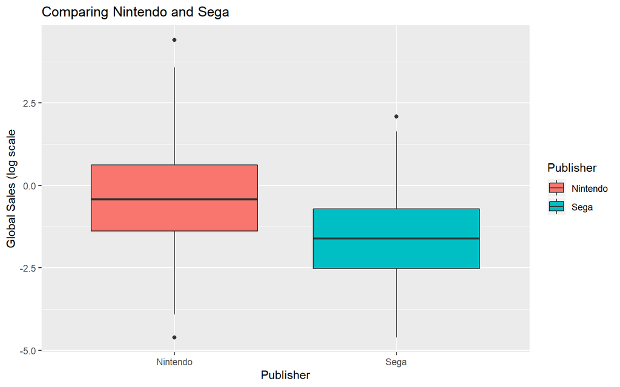

## Answer a question

A group of parents is concerned with the the rise in violent video games. What do you think of this concern? Is it merited?

## Challenge: Learn a new R skill

Complete this section for 10 flex points.

There is a function in R called `gather`, or if your packages `tidyr` is newly updated, you can use a newer version called `pivot_longer`. Let’s learn how to use this.

Right now, our dataset looks like this:

```
## # A tibble: 14,003 x 11
##     Rank Name  Platform  Year Genre Publisher NA_Sales EU_Sales JP_Sales
##    <dbl> <chr> <chr>    <dbl> <chr> <chr>        <dbl>    <dbl>    <dbl>
##  1     1 Wii ~ Wii       2006 Spor~ Nintendo     41.5     29.0      3.77
##  2     3 Mari~ Wii       2008 Raci~ Nintendo     15.8     12.9      3.79
##  3     4 Wii ~ Wii       2009 Spor~ Nintendo     15.8     11.0      3.28
##  4     7 New ~ DS        2006 Plat~ Nintendo     11.4      9.23     6.5
##  5     8 Wii ~ Wii       2006 Misc  Nintendo     14.0      9.2      2.93
##  6     9 New ~ Wii       2009 Plat~ Nintendo     14.6      7.06     4.7
##  7    11 Nint~ DS        2005 Simu~ Nintendo      9.07    11        1.93
##  8    12 Mari~ DS        2005 Raci~ Nintendo      9.81     7.57     4.13
##  9    14 Wii ~ Wii       2007 Spor~ Nintendo      8.94     8.03     3.6
## 10    15 Wii ~ Wii       2009 Spor~ Nintendo      9.09     8.59     2.53
## # ... with 13,993 more rows, and 2 more variables: Other_Sales <dbl>,
## #   Global_Sales <dbl>
```

Your goal will be to make a dataset that looks like this:

```
## # A tibble: 42,009 x 4
##    Name                  Publisher Location Num_Sales
##    <chr>                 <chr>     <chr>        <dbl>
##  1 Wii Sports            Nintendo  NA_Sales     41.5
##  2 Wii Sports            Nintendo  EU_Sales     29.0
##  3 Wii Sports            Nintendo  JP_Sales      3.77
##  4 Mario Kart Wii        Nintendo  NA_Sales     15.8
##  5 Mario Kart Wii        Nintendo  EU_Sales     12.9
##  6 Mario Kart Wii        Nintendo  JP_Sales      3.79
##  7 Wii Sports Resort     Nintendo  NA_Sales     15.8
##  8 Wii Sports Resort     Nintendo  EU_Sales     11.0
##  9 Wii Sports Resort     Nintendo  JP_Sales      3.28
## 10 New Super Mario Bros. Nintendo  NA_Sales     11.4
## # ... with 41,999 more rows
```

Figure out how to use either `pivot_longer` or `gather` to accomplish this. You will probably want to Google around for help with this, and/or to look at the documentation using `?gather` or `?pivot_longer`

Here is a start:

```r
vgames %>%
  select(Name, Publisher, NA_Sales, EU_Sales, JP_Sales) %>%
  pivot_longer(???????)
```

Stat 150